# Evaluating State-Level COVID-19 Death Forecasts and County-Level Case Forecasts

Delphi Group

December 11, 2020

## Get forecasts from COVID Hub

First fetch forecast dates for a bunch of forecasters. **TODO** (this is more of a general one to make this notebook better, and not specific to evalcast dev): we should do this more comprehensively. Pull all forecasters that have enough submissions to make useful comparisons. To do this, we can expose the function `get_covidhub_forecaster_names()`.

```r
forecasters = c("CMU-TimeSeries",
             #   "YYG-ParamSearch",
             #   "UMass-MechBayes",
             #   "GT-DeepCOVID",
             #   "IHME-CurveFit",
             #   "LANL-GrowthRate",
             #   "UCLA-SuEIR",
             #   "MOBS-GLEAM_COVID",
             #  "UT-Mobility",
             #  "OliverWyman-Navigator",
             #  "JHU_IDD-CovidSP",
             #   "CovidAnalytics-DELPHI",
             #   "Google_Harvard-CPF", Excluded for now. Doesn't have quantiles for all forecasts
             #   "Yu_Group-CLEP",
                "COVIDhub-ensemble",
                "COVIDhub-baseline")

# Get all forecast dates for these forecasters from COVID Hub
forecast_dates = vector("list", length = length(forecasters))
for (i in 1:length(forecasters)) {
  forecast_dates[[i]] = tryCatch({
    as_date(get_forecast_dates(forecasters[i]))
  },
  error = function(e) cat(sprintf("%i. %s\n", i, e$message))
  )
}
```

Load data from previous run so we don’t have to reingest / process it. This data could end up out of date if a forecast is retrospectively updated, but in that case it’s no longer a true prediction. We can always restart from scratch by deleting covidhub_evaluation.rda.

```r
load(file = "covidhub_evaluation.rda")
if(exists("predictions_cards")){
seen_dates = predictions_cards %>%
  distinct(forecast_date, forecaster)
}
```

Now figure out “comparable” forecast dates: making a forecast on a Sunday or a Monday of the same epiweek should be comparable. **TODO**: we should switch over to using the Zoltar API, and soon it should have an “as of” parameter, so then we shouldn’t need to do this.

```r
forecast_dates_cmu = forecast_dates[[1]]
# new_dates, as opposed to dates for which we already have data for a forecaster
new_dates = list()
for (i in 1:length(forecasters)) {
  given_dates = forecast_dates[[i]]
  # If the dates match exactly, or the given date falls on a Sunday and the
  # CMU date falls on a Monday of the same epiweek, then call it comparable...
  comparable_forecast_dates = given_dates[(given_dates %in% forecast_dates_cmu |
                            ((given_dates + 1) %in% forecast_dates_cmu) &
                            wday(given_dates) == 1)]

  # ...but if there is an exact match on dates, ignore predictions made on the
  # previous day
  comparable_forecast_dates = comparable_forecast_dates[!((comparable_forecast_dates + 1) %in% comparable_forecast_dates)]
  if(exists("seen_dates")){
    if(forecasters[[i]] %in% seen_dates$forecaster){
      seen_forecaster_dates = (seen_dates %>%
                                filter(forecaster == forecasters[[i]]))$forecast_date
      comparable_forecast_dates = as_date(setdiff(comparable_forecast_dates, seen_forecaster_dates))
    }
  }
  new_dates[[i]] = comparable_forecast_dates
}
names(new_dates) = forecasters
```

Now get predictions for each forecaster, looping over forecast dates from the CMU-TimeSeries model. **TODO**: this part is very very slow. Maybe (hopefully) by changing to use the Zoltar API, this will be much faster.

```r
predictions_cards_list = vector("list", length = length(forecasters))
deaths_sig = "deaths_incidence_num"
cases_sig = "confirmed_incidence_num"
for (i in 1:length(forecasters)) {
  cat(forecasters[i], "...\n")
  if (length(new_dates[[i]] > 0)){
  predictions_cards_list[[i]] = tryCatch({
    get_covidhub_predictions(forecasters[i],
                             rev(new_dates[[i]])) %>%
                    filter(ahead < 5) %>%
                    filter((nchar(geo_value) == 2 & signal == deaths_sig) |
                           (nchar(geo_value) == 5 & signal == cases_sig))
  },
  error = function(e) cat(e$message))
  }
}
```

```
## CMU-TimeSeries ...
## COVIDhub-ensemble ...
## COVIDhub-baseline ...
```

```r
predictions_cards_new = bind_rows(predictions_cards_list)

# Combine old and new predictions cards
if(exists("predictions_cards")){
  predictions_cards = rbind(predictions_cards, predictions_cards_new)
} else {
  predictions_cards = predictions_cards_new
}

# Discard any forecasters without data
forecasters = unique(as.data.frame(predictions_cards)$forecaster)
```

On reflection: part of the problem here is that `get_covidhub_predictions()` downloads *all* predictions from COVID Hub and *then* filters them as needed. This makes the above extra slow because we end up downloading state and county forecasts, when we just want state forecasts. **TODO**: even before switching over to use the Zoltar API, we should redesign `get_covidhub_predictions()` so that it fetches from GitHub only the forecasts we specify, if possible.

## Evaluate predictions

Hack: must change the response data source to be USAFacts, as JHU-CSSE data is currently unstable. **TODO**: we shouldn’t require `evaluate_predictions()` to have the response match what’s in the forecaster. If I train my forecaster on (say) JHU-CSSE data, then I should be able to evaluate it on USAFacts data.

```r
predictions_cards$data_source = "usa-facts"
```

Evaluate the predictions based on weighted interval score (WIS), absolute error (AE), and coverage of the central 80% prediction interval. **TODO**: we need to make sure evalcast “fails gracefully” in as many places as possible, and doesn’t throw an error (which would halt all execution) when it should be instead just throwing a warning and moving on. Basically I needed to artifically trim the forecast dates to have the latest one by “2020-09-28” so that I wouldn’t get errors with the aheads here. This is undesirable obviously …

Also, another **TODO**: just want to note that this is again very slow. Caching would help but I don’t think it’s the right solution. We’re fetching the exact same data something like 15 times in a row. If we simply changed the order of operations then we wouldn’t even need caching at all.

```r
err_measures = list(wis = weighted_interval_score, ae = absolute_error,
                    cov_80 = interval_coverage(coverage = 0.8))

preds_to_eval = predictions_cards %>%
                      filter(target_end_date < today())

preds_to_eval_state = preds_to_eval %>%
                        filter(nchar(geo_value) == 2)

if(exists("score_cards_state")){
  preds_to_eval_state = anti_join(preds_to_eval_state,
                                  score_cards_state,
                                  by = c("ahead", "forecaster", "forecast_date"))
}

if(nrow(preds_to_eval_state) > 0){
  score_cards_new_state = evaluate_predictions(preds_to_eval_state,
                                              err_measures,
                                              backfill_buffer = 0)
} else {
  score_cards_new_state = data.frame()
}

if(exists("score_cards_state")){
  score_cards_state = rbind(score_cards_state, score_cards_new_state)
} else {
  score_cards_state = score_cards_new_state
}

preds_to_eval_county = preds_to_eval %>%
                        filter(nchar(geo_value) == 5)

if(exists("score_cards_county")){
  preds_to_eval_county = anti_join(preds_to_eval_county,
                                  score_cards_county,
                                  by = c("ahead", "forecaster", "forecast_date"))
}

if(nrow(preds_to_eval_county) > 0){
  evaluable_forecasters = (preds_to_eval_county %>%
                            distinct(forecaster, quantile) %>%
                            filter(!is.na(quantile)) %>%
                            count(forecaster) %>%
                            filter(n > 1))$forecaster
  preds_to_eval_county = preds_to_eval_county %>%
                           filter(forecaster %in% evaluable_forecasters)
}
if(nrow(preds_to_eval_county) > 0){
  score_cards_new_county = evaluate_predictions(preds_to_eval_county,
                                              err_measures,
                                              backfill_buffer = 0)
} else {
  score_cards_new_county = data.frame()
}

if(exists("score_cards_county")){
  score_cards_county = rbind(score_cards_county, score_cards_new_county)
} else {
  score_cards_county = score_cards_new_county
}
```

As the above contained some pretty expensive steps, we save the results in an RData file (and we set `eval = FALSE` on this and all the above code chunks).

```r
save(list = c("predictions_cards", "score_cards_county", "score_cards_state"),
     file = "covidhub_evaluation.rda",
     compress = "xz")
rm(list = setdiff(ls(),
                  c("predictions_cards",
                    "score_cards_county",
                    "score_cards_state")))
```

Compute summary statistics.

```r
# load(file = "covidhub_evaluation.rda")
recent_score_by_frcstr = score_cards_state %>%
                           filter(target_end_date > today() - 28) %>%
                           group_by(forecaster, ahead) %>%
                           summarize(num = sum(!is.na(wis))) %>%
                           pivot_wider(names_from = ahead,
                                       names_prefix = "num_",
                                       values_from = num)
recent_score_by_frcstr = recent_score_by_frcstr %>%
                           mutate(num_total = num_1 + num_2 + num_3 + num_4) %>%
                           arrange(desc(num_total))
print(recent_score_by_frcstr, n = Inf)
```

```
## # A tibble: 3 x 6
## # Groups:   forecaster [3]
##   forecaster        num_1 num_2 num_3 num_4 num_total
##   <chr>             <int> <int> <int> <int>     <int>
## 1 CMU-TimeSeries     4896  4896  4896  4896     19584
## 2 COVIDhub-baseline  4896  4896  4896  4896     19584
## 3 COVIDhub-ensemble  4896  4896  4896  4896     19584
```

```r
max_forecasts = 51 * 24 * 4 * 4 # States * quantiles * ahead * weeks

active_forecasters = recent_score_by_frcstr[recent_score_by_frcstr$num_total > max_forecasts / 2,]$forecaster
# CovidAnalytics-DELPHI and IHME-CurveFit didn't submit that many forecasts ...
score_cards_state = score_cards_state %>%
                    filter(forecaster %in% active_forecasters)

recent_score_by_frcstr = score_cards_county %>%
                           filter(target_end_date > today() - 28) %>%
                           group_by(forecaster, ahead) %>%
                           summarize(num = sum(!is.na(wis))) %>%
                           pivot_wider(names_from = ahead,
                                       names_prefix = "num_",
                                       values_from = num)
recent_score_by_frcstr = recent_score_by_frcstr %>%
                           mutate(num_total = num_1 + num_2 + num_3 + num_4) %>%
                           arrange(desc(num_total))
print(recent_score_by_frcstr, n = Inf)
```

```
## # A tibble: 3 x 6
## # Groups:   forecaster [3]
##   forecaster         num_1  num_2  num_3  num_4 num_total
##   <chr>              <int>  <int>  <int>  <int>     <int>
## 1 COVIDhub-baseline 100544 100544 100544 100544    402176
## 2 COVIDhub-ensemble 100544 100544 100544 100544    402176
## 3 CMU-TimeSeries      6400   6400   6400   6400     25600
```

```r
active_forecasters = recent_score_by_frcstr[recent_score_by_frcstr$num_total > 10000,]$forecaster
# CovidAnalytics-DELPHI and IHME-CurveFit didn't submit that many forecasts ...
score_cards_county = score_cards_county %>%
                    filter(forecaster %in% active_forecasters)
```

## Dot plots

First we make dot plots (not the same as that in evalcast): one dot per ahead, forecaster, and forecast date. The red plus marks the score computed over all dates. Here we use the mean as the aggregator function, and we study WIS, AE, and coverage-80.

```r
# Define mean and median functions that deal with missingness well
Mean = function(x) mean(x, na.rm = TRUE)
Median = function(x) median(x, na.rm = TRUE)

summarize_var = function(df, var, aggr = Mean) {
  df_by_date = df %>%
    group_by(forecaster, ahead, target_end_date) %>%
    summarize(var = aggr(!!as.symbol(var))) %>%
    ungroup()
  df_overall = df %>%
    group_by(forecaster, ahead) %>%
    summarize(var_overall = aggr(!!as.symbol(var))) %>%
    ungroup() %>% group_by(ahead) %>%
    arrange(var_overall, .by_group = TRUE) %>%
    ungroup() %>%
    mutate(order = row_number())
  df_sum = full_join(df_by_date, df_overall, by = c("forecaster", "ahead"))
}

dot_plot = function(df, var = "wis", ylab = var, ylim = NULL, aggr = Mean) {
  df_sum = summarize_var(df, var, aggr)
  df_sum$ahead = factor(paste("ahead =", df_sum$ahead))

  ggplot(df_sum, aes(x = order, y = var)) +
    geom_point(aes(color = target_end_date)) +
    geom_point(aes(x = order, y = var_overall), color = "red", shape = 3) +
    facet_wrap(vars(ahead), scales = "free") +
    labs(x = "Forecaster", y = ylab) +
    scale_x_continuous(breaks = df_sum$order, labels = df_sum$forecaster) +
    theme(axis.text.x = element_text(angle = 90, hjust = 1, size = 8)) +
    coord_cartesian(ylim = ylim)
}
```

### States

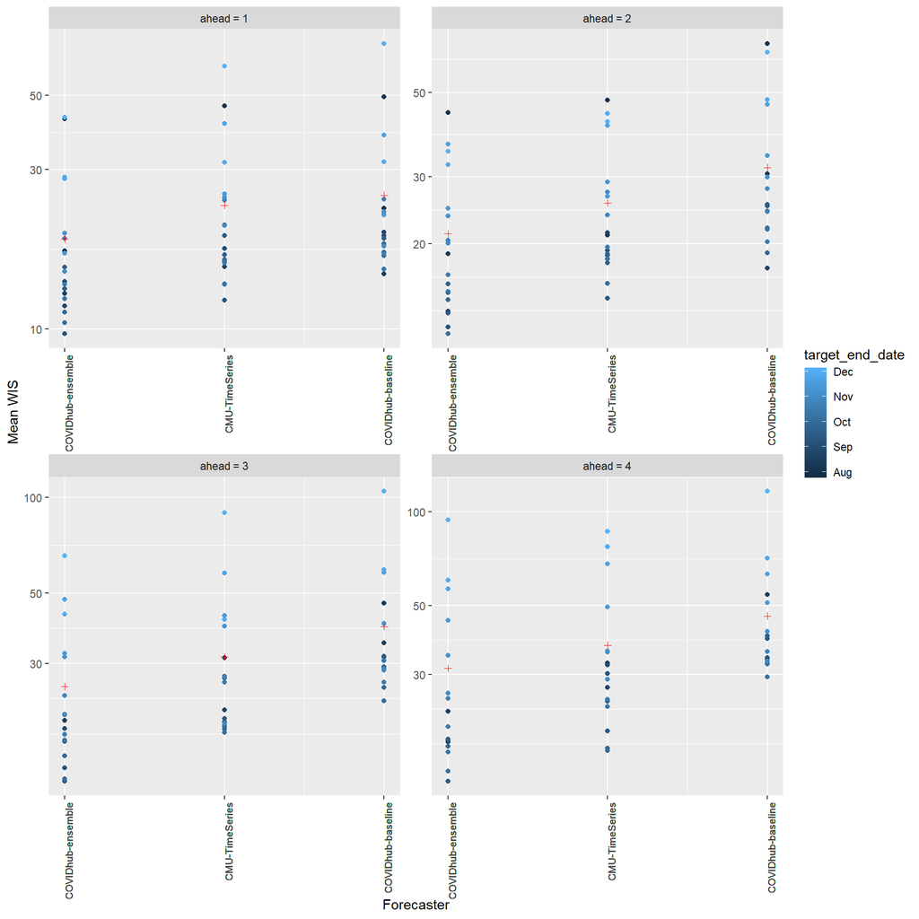

```r
dot_plot(score_cards_state, var = "wis", ylab = "Mean WIS") + scale_y_log10()
```

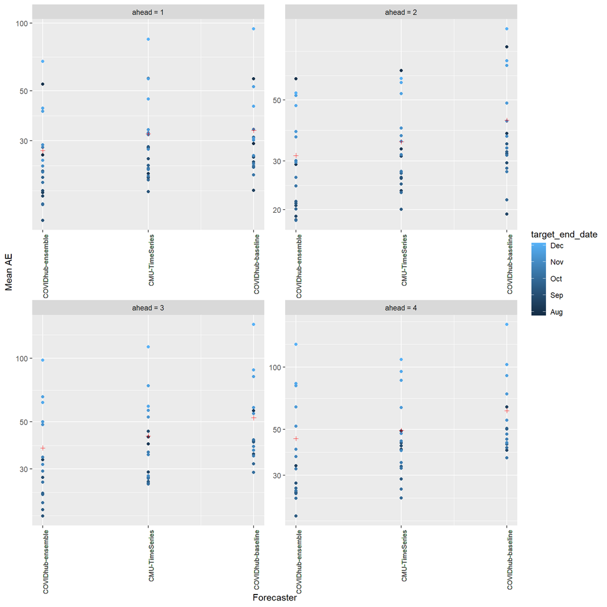

```r
dot_plot(score_cards_state, var = "ae", ylab = "Mean AE") + scale_y_log10()
```

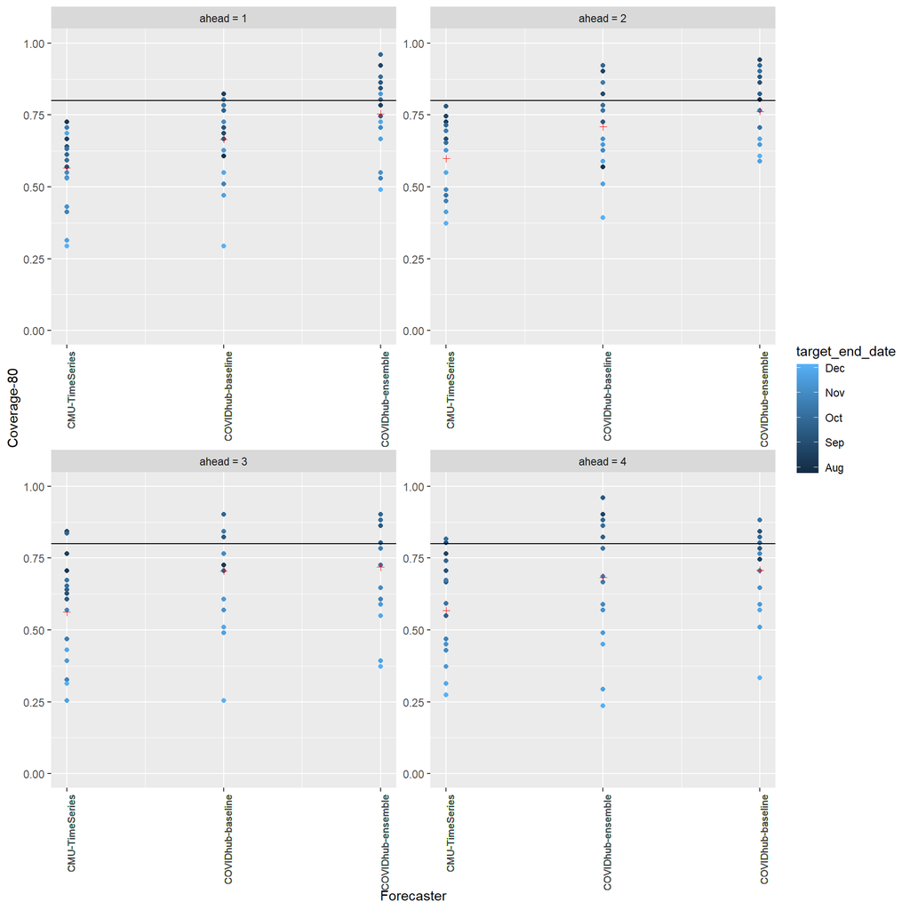

```r
dot_plot(score_cards_state, var = "cov_80", ylab = "Coverage-80", ylim = c(0,1)) +
  geom_hline(yintercept = 0.8)
```

### Counties

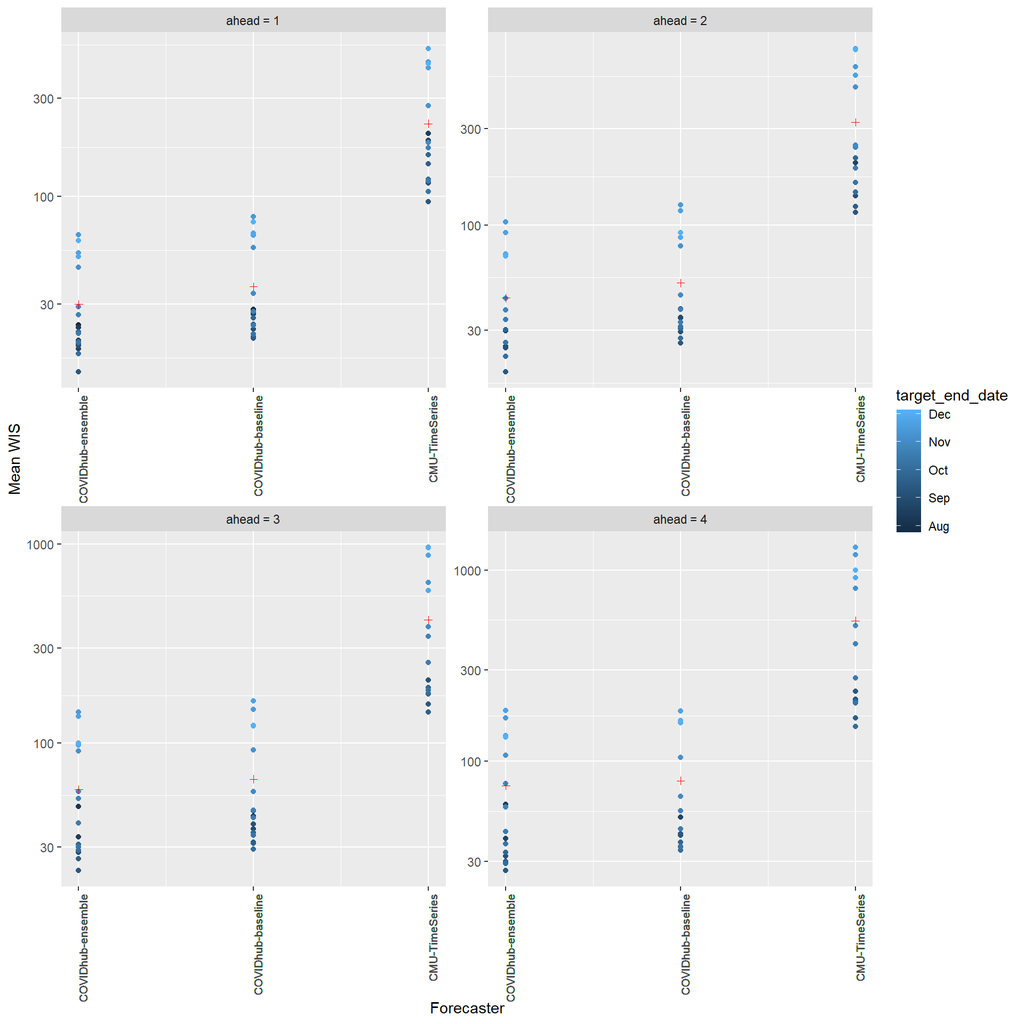

```r
dot_plot(score_cards_county, var = "wis", ylab = "Mean WIS") + scale_y_log10()
```

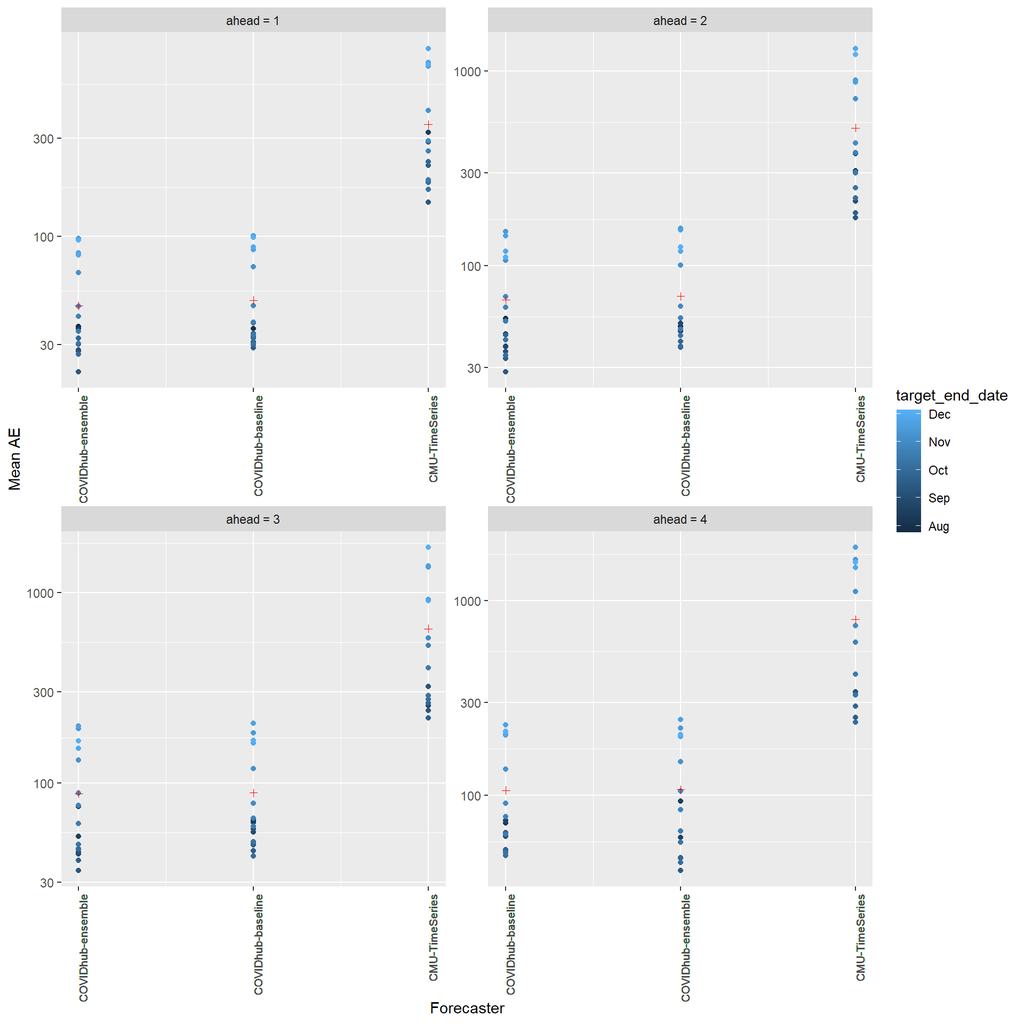

```r
dot_plot(score_cards_county, var = "ae", ylab = "Mean AE") + scale_y_log10()
```

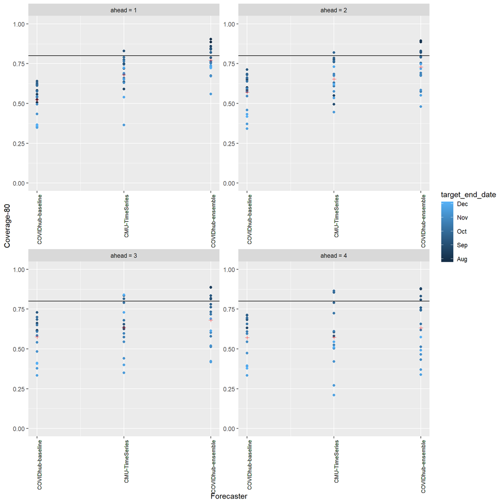

```r
dot_plot(score_cards_county, var = "cov_80", ylab = "Coverage-80", ylim = c(0,1)) +
  geom_hline(yintercept = 0.8)
```

## Dot plots: median and 90th percentile

Same as before, but change the aggregator function to the median. Omitting AE for brevity, hencforth.

### States

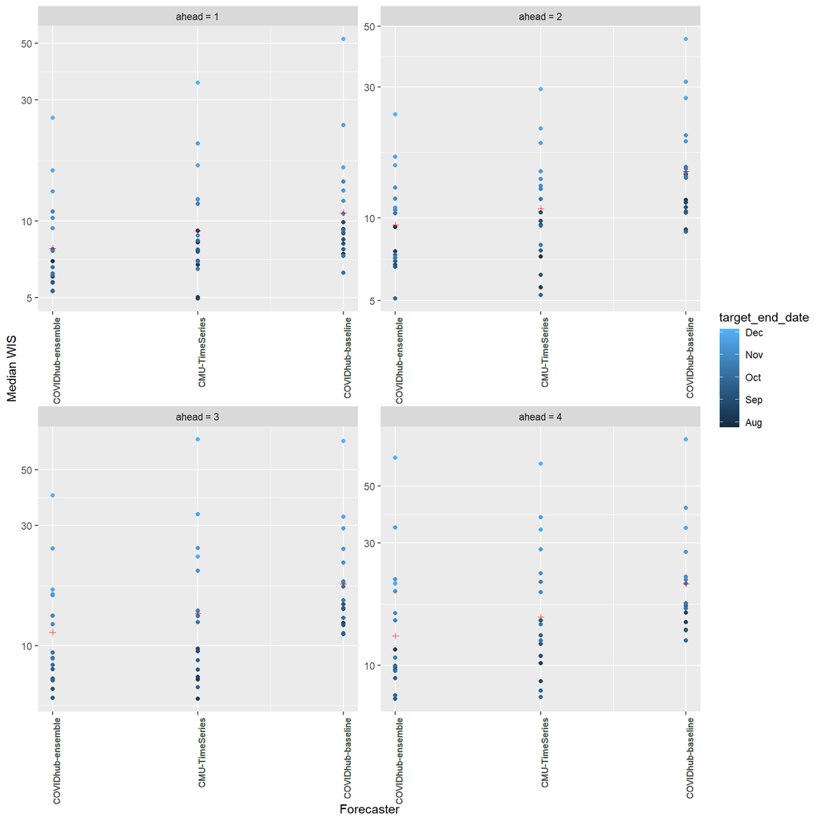

```r
dot_plot(score_cards_state, var = "wis", ylab = "Median WIS", aggr = Median) +
  scale_y_log10()
```

### Counties

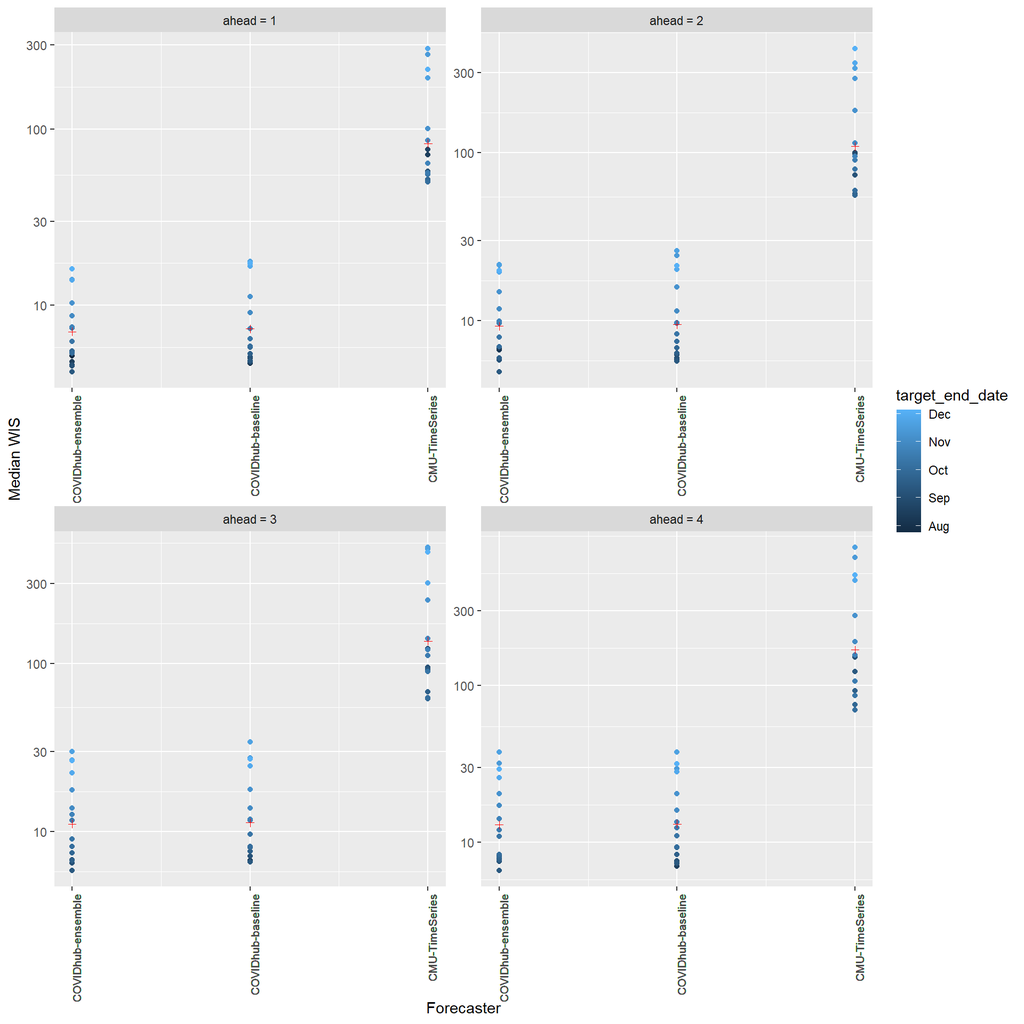

```r
dot_plot(score_cards_county, var = "wis", ylab = "Median WIS", aggr = Median) +
  scale_y_log10()
```

And now we change the aggregator function to be the 90th percentile.

### States

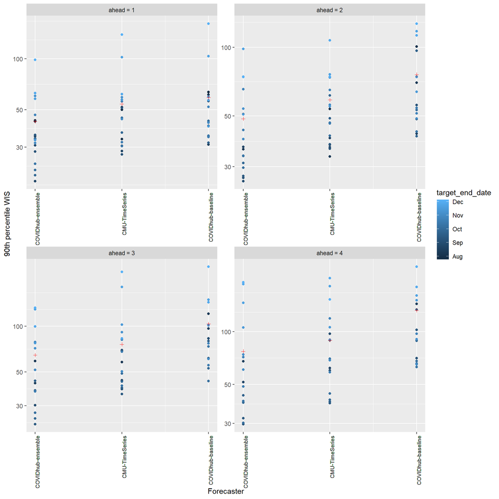

```r
dot_plot(score_cards_state, var = "wis", ylab = "90th percentile WIS",
         aggr = function(x) quantile(x, prob = 0.9, na.rm = TRUE)) +
  scale_y_log10()
```

### Counties

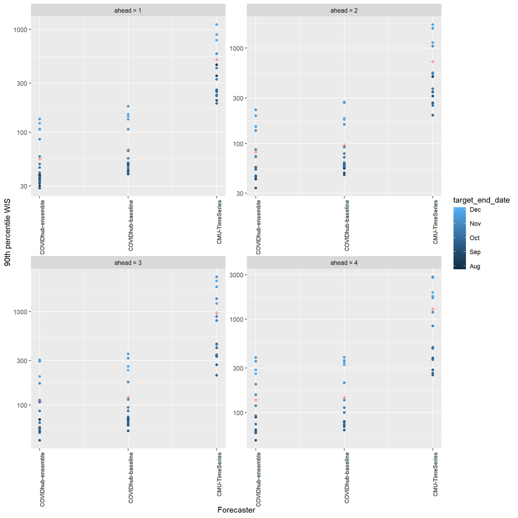

```r
dot_plot(score_cards_county, var = "wis", ylab = "90th percentile WIS",
         aggr = function(x) quantile(x, prob = 0.9, na.rm = TRUE)) +
  scale_y_log10()
```

## Line plots

Now we make line plots: one line per ahead and forecaster, as a function of f orecast date. Here we use the mean as the aggregator function, and we look at WIS and coverage-80.

```r
# From https://stackoverflow.com/questions/15282580/
color_picker = function(n) {
  qual_col_pals = brewer.pal.info[brewer.pal.info$category == 'qual',]
  unlist(mapply(brewer.pal, qual_col_pals$maxcolors, rownames(qual_col_pals)))
}

line_plot = function(df, var = "wis", ylab = var, ylim = NULL, aggr = Mean) {
  df_sum = summarize_var(df, var, aggr)
  df_sum$ahead = factor(paste("ahead =", df_sum$ahead))

  ggplot(df_sum, aes(x = target_end_date, y = var)) +
    geom_line(aes(color = forecaster, linetype = forecaster)) +
    geom_point(aes(color = forecaster)) +
    facet_wrap(vars(ahead), scales = "free") +
    labs(x = "Date", y = ylab) +
    coord_cartesian(ylim = ylim) +
    scale_color_manual(values = color_picker(length(unique(forecaster))))
}
```

### States

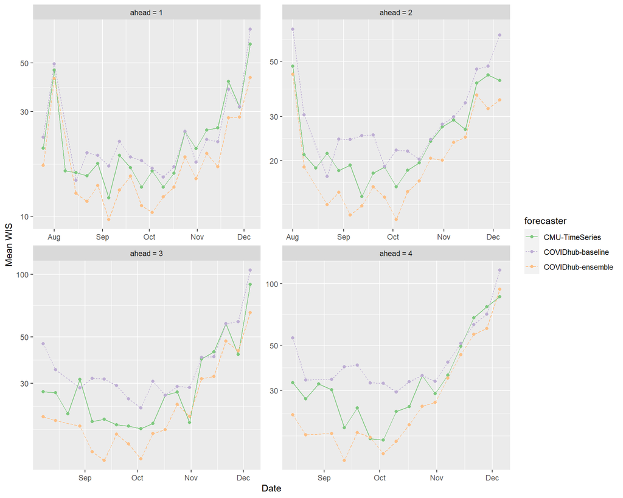

```r
line_plot(score_cards_state, var = "wis", ylab = "Mean WIS") + scale_y_log10()
```

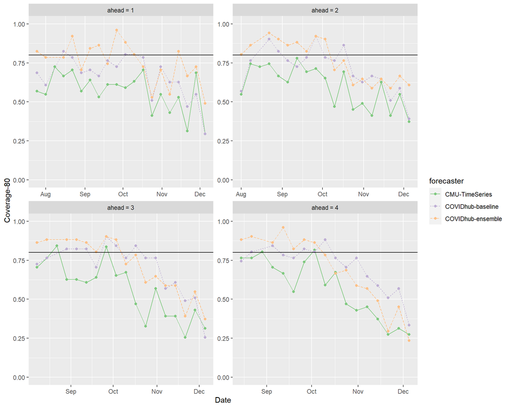

```r
line_plot(score_cards_state, var = "cov_80", ylab = "Coverage-80", ylim = c(0,1)) +
  geom_hline(yintercept = 0.8)
```

### Counties

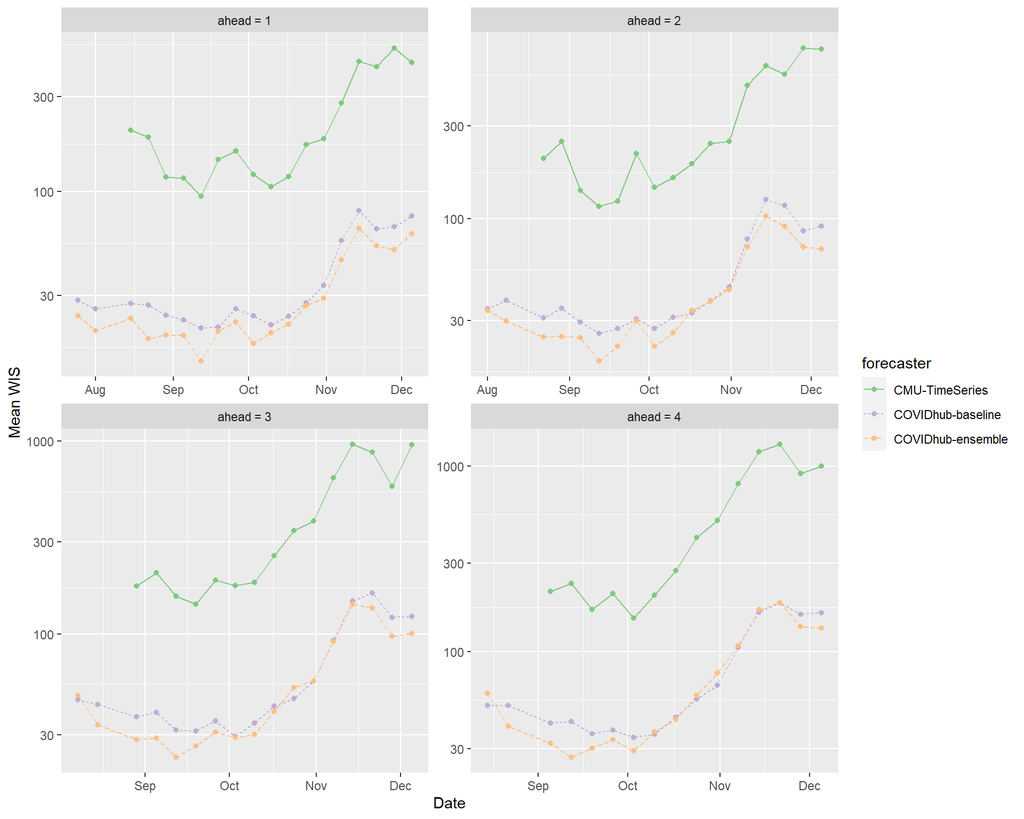

```r
line_plot(score_cards_county, var = "wis", ylab = "Mean WIS") + scale_y_log10()
```

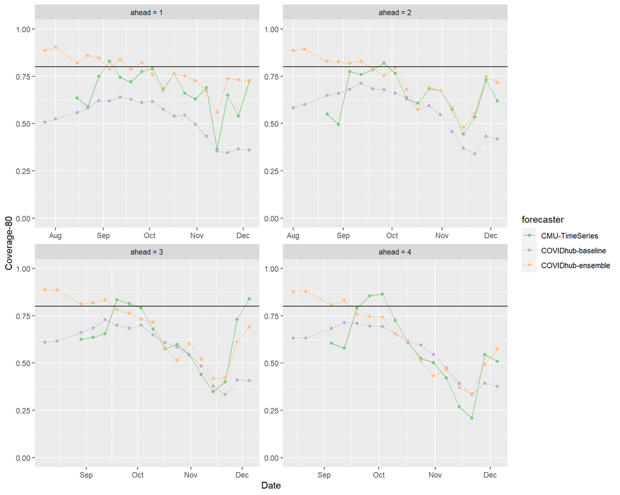

```r
line_plot(score_cards_county, var = "cov_80", ylab = "Coverage-80", ylim = c(0,1)) +
  geom_hline(yintercept = 0.8)
```

## Scaling by baseline

We scale each score, per location and forecast date, by the COVIDhub-baseline score; then we take the mean or median.

Important note on the order of operations here: scale then aggregate. The other way around: aggregate then scale, would be a simple post-adjustment applied to the metrics we computed earlier. This way: scale then aggregate, results in a different final metric altogether. It is potentially interesting as it provides a nonparametric spatiotemporal adjustment; assuming that space and time effects are *multiplicative*, we’re directly “canceling them out” by taking ratios.

Here are dot plots for scaled WIS, with mean as the aggregator. Omitting median for brevity.

```r
# Note to self: mutate_at() gave me a weird bug below! From now on, better use
# mutate() with across() instead ...
scale_df = function(df, var, base_forecaster = "COVIDhub-baseline") {
  df %>% select(-c(quantile, value, forecast_date)) %>%
    distinct() %>%
    pivot_wider(id_cols = c(geo_value, target_end_date, ahead),
                names_from = "forecaster", names_prefix = var,
                values_from = var) %>%
    mutate(across(starts_with(var), ~ .x /
                !!as.symbol(paste0(var, base_forecaster)))) %>%
    pivot_longer(cols = starts_with(var), names_to = "forecaster",
                 values_to = "scaled") %>%
    mutate(forecaster = substring(forecaster, nchar(var) + 1)) %>%
    filter(forecaster != base_forecaster)
}
```

### States

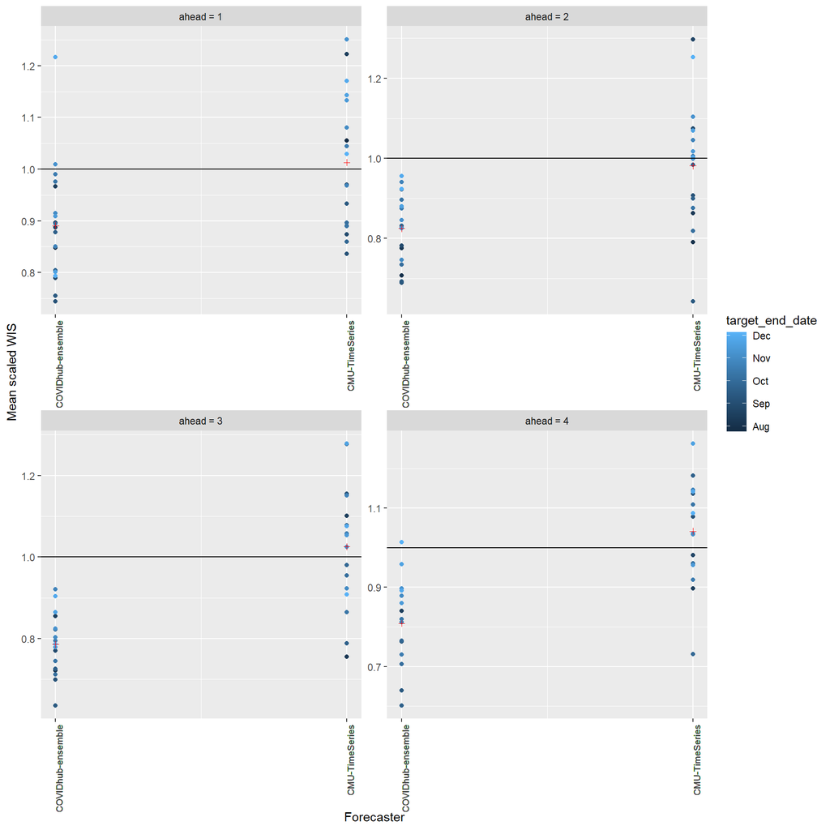

```r
dot_plot(scale_df(score_cards_state, var = "wis"), var = "scaled",
         ylab = "Mean scaled WIS") + geom_hline(yintercept = 1)
```

### Counties

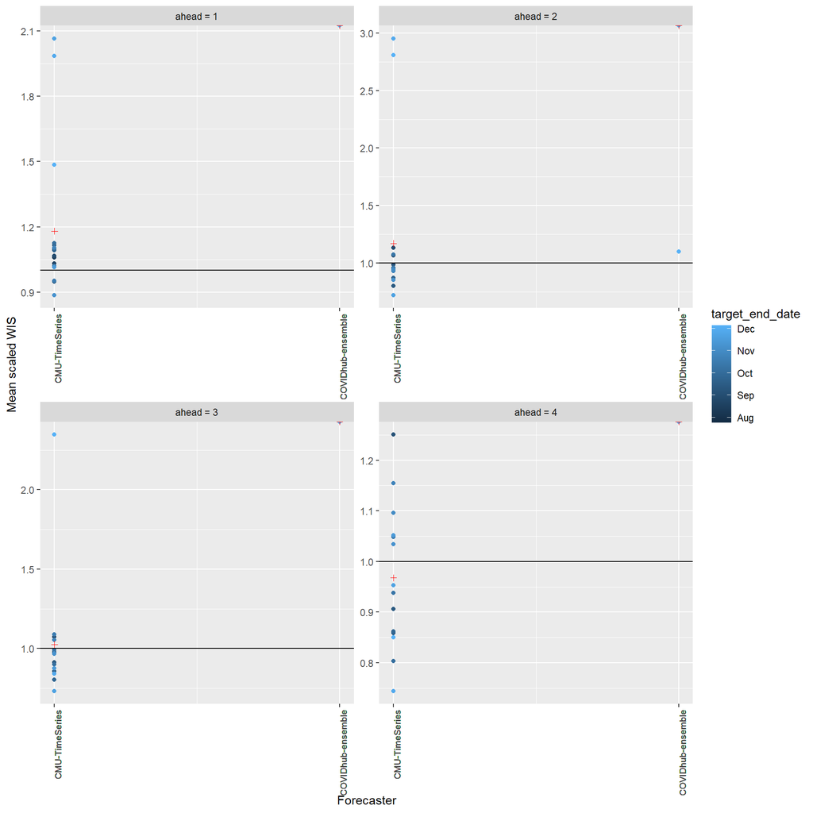

```r
dot_plot(scale_df(score_cards_county, var = "wis"), var = "scaled",
         ylab = "Mean scaled WIS") + geom_hline(yintercept = 1)
```

Here are now line plots for mean scaled WIS.

### States

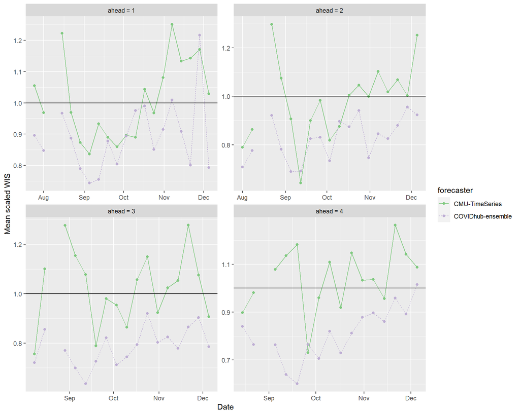

```r
line_plot(scale_df(score_cards_state, var = "wis"), var = "scaled",
          ylab = "Mean scaled WIS") + geom_hline(yintercept = 1)
```

### Counties

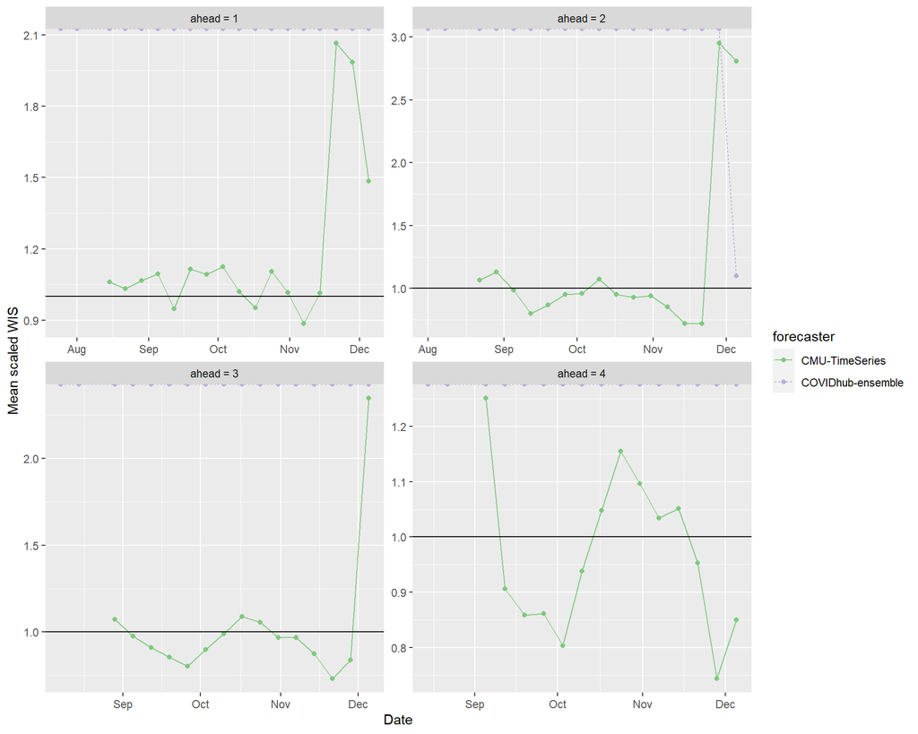

```r
line_plot(scale_df(score_cards_county, var = "wis"), var = "scaled",
          ylab = "Mean scaled WIS") + geom_hline(yintercept = 1)
```

## Centering by baseline

Similar to what we did previously but just with centering instead of scaling.

Note on order of operations: center then aggregate versus aggregate then center are still in general different strategies. As before we’re adhering to the first way, with a similar movitation: if space and time effects were now *additive*, then this way would “cancel them out” directly. However, when the aggregator is a linear operation (e.g., mean), the two strategies essentially reduce to the same thing (“essentially”, not exactl, because setting `na.rm = TRUE` generally turns any linear operator into a nonlinear one).

Here are the dot plots for mean centered WIS. Omitting median for brevity.

```r
center_df = function(df, var, base_forecaster = "COVIDhub-baseline") {
  scale_df(df %>% mutate(y = exp(!!as.symbol(var))), "y", base_forecaster) %>%
    mutate(centered = log(scaled)) %>% select(-scaled)
}
```

### States

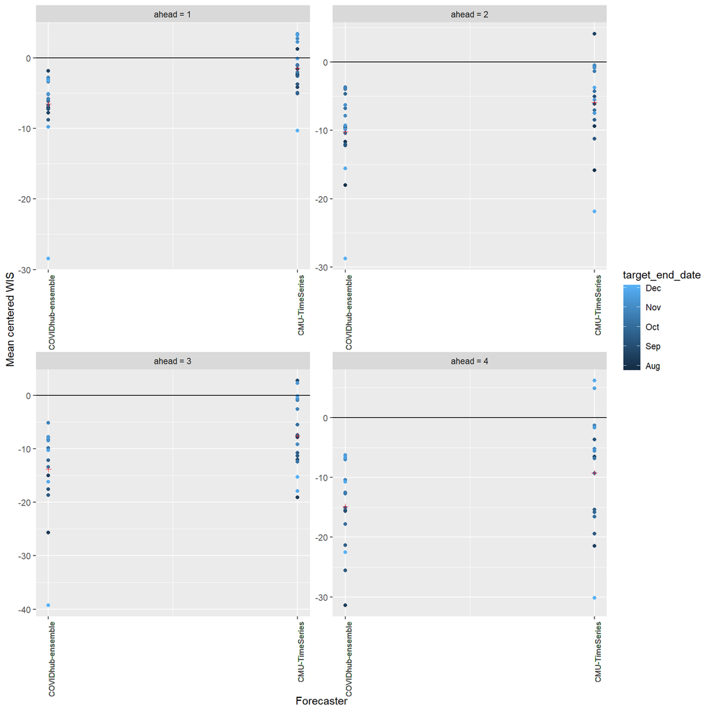

```r
dot_plot(center_df(score_cards_state, var = "wis"), var = "centered",
         ylab = "Mean centered WIS") + geom_hline(yintercept = 0)
```

### Counties

[figure not shown]

```r
dot_plot(center_df(score_cards_county, var = "wis"), var = "centered",
         ylab = "Mean centered WIS") + geom_hline(yintercept = 0)
```

Here are now the line plots for mean centered WIS.

### States

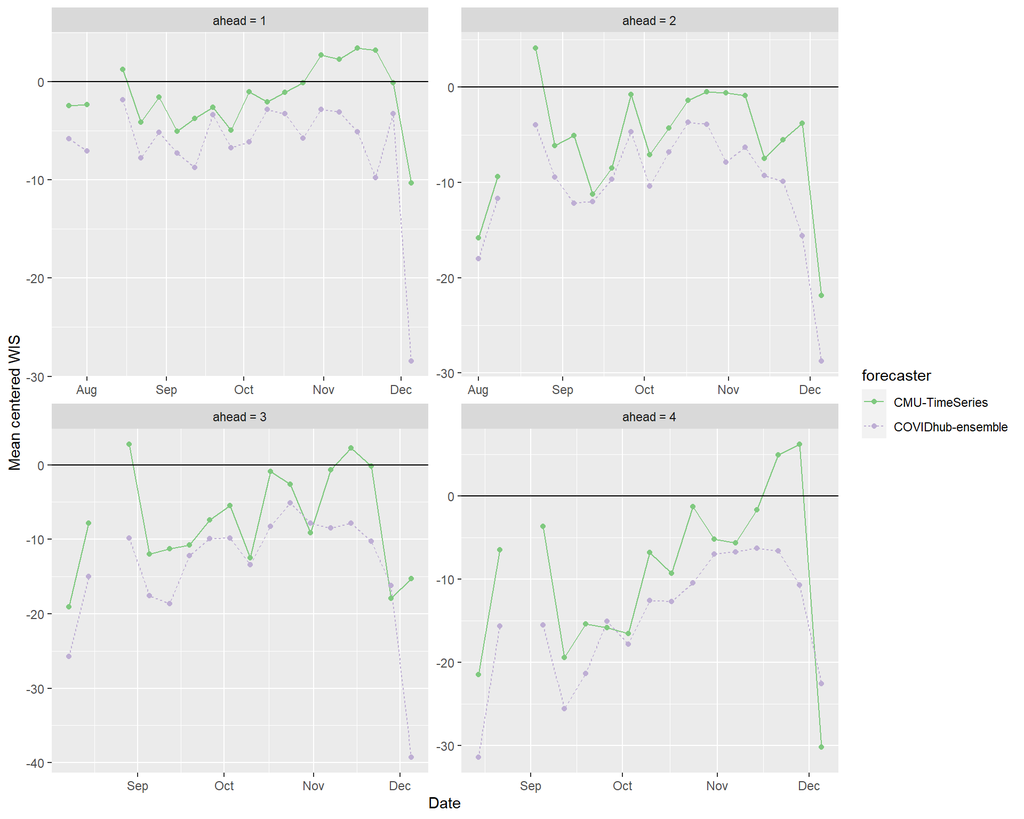

```r
line_plot(center_df(score_cards_state, var = "wis"), var = "centered",
          ylab = "Mean centered WIS") + geom_hline(yintercept = 0)
```

### Counties

[figure not shown]

```r
line_plot(center_df(score_cards_county, var = "wis"), var = "centered",
          ylab = "Mean centered WIS") + geom_hline(yintercept = 0)
```

## Pairwise tournament

We run a pairwise tournament. This is inspired by Johannes Bracher’s analysis (and similar ideas in the literature). Except, the order of operations here is different: scale then aggregate (whereas Johannes did: aggregate then scale). The motivation for this was explained above (thinking of it as providing a nonparametric spatiotemporal adjustment), as was the fact that the order of operations really makes a difference.

For each pair of forecasters $f$ and $g$, we compute:

$$\theta_{fg} = A\bigg\{ \frac{S(f;\ell,d,a)}{S(g;\ell,d,a)} \;:\; \text{common
locations $\ell$, forecast dates $d$, and ahead values $a$} \bigg\}$$

where $S$ is a score of interest, say WIS, and $A$ is an aggregator of interest, say the mean. Important note: we aggregate over *all common locations, dates, and ahead values*, which may differ for each pair $f,g$. To compute an overall metric for forecaster $f$, we use:

$$\theta_f = \bigg( \prod_g \theta_{fg} \bigg)^{1/F}.$$

the geometric mean of all pairwise comparisons of $f$ to other forecasters (here $F$ is the total number of forecasters). Another interesting option would be to define $(\theta_f)_{f \in F}$ as the top left singular vector of the matrix $(\theta_{fg})_{f,g \in F}$, which we’ll also investigate.

```r
pairwise_tournament = function(df, var, aggr = Mean) {
  forecasters = unique(df$forecaster)
  theta_mat = matrix(NA, length(forecasters), length(forecasters))
  rownames(theta_mat) = colnames(theta_mat) = forecasters
  for (f in forecasters) {
    result =  scale_df(df, var, base_forecaster = f) %>%
      group_by(forecaster) %>%
      summarize(v = aggr(scaled))
    theta_mat[result$forecaster, f] = result$v
  }

  # Convert to data frame for convenience with ggplot
  theta_df = as.data.frame(theta_mat) %>%
    mutate(Forecaster1 = forecasters) %>%
    pivot_longer(cols = -Forecaster1, names_to = "Forecaster2",
                 values_to = "value")

  # Compute overall metrics two ways: geometric mean, SVD
  theta_vec1 = exp(rowMeans(log(theta_mat), na.rm = TRUE))
  diag(theta_mat) = 1 # so the SVD won't fail; undo it later
  theta_vec2 = as.numeric(svd(theta_mat, nu = 1)$u)
  names(theta_vec2) = names(theta_vec1)
  diag(theta_mat) = NA

  return(list(mat = theta_mat, df = theta_df, vec1 = theta_vec1,
              vec2 = theta_vec2))
}
```

### States

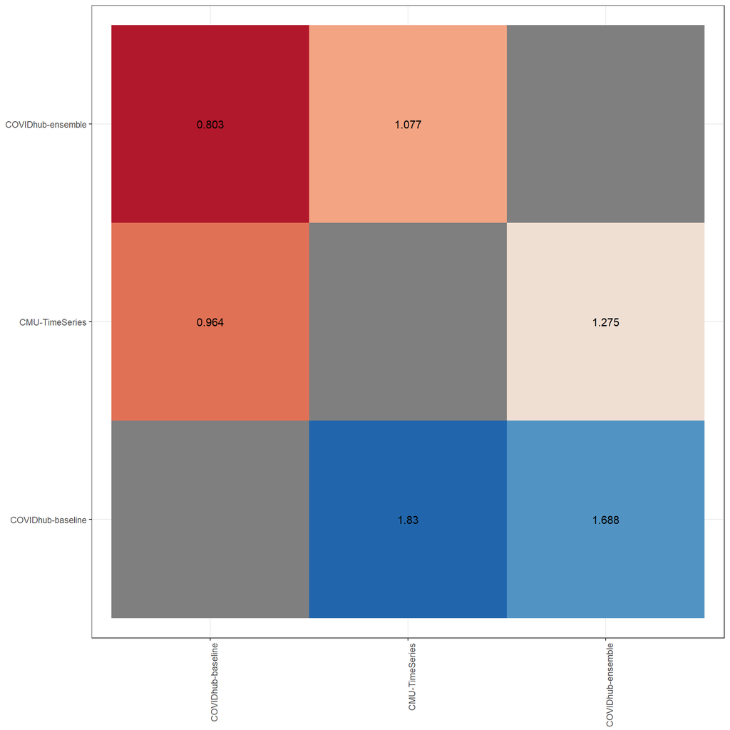

```r
theta_state = pairwise_tournament(score_cards_state, var = "wis", aggr =
                              function(x) mean(x, trim = 0.01, na.rm = TRUE))
ranked_list = rownames(theta_state$mat)[order(theta_state$vec1)]
colors = colorRampPalette(brewer.pal(n = 6, name = "RdBu"))(30)
ggplot(theta_state$df, aes(x = factor(Forecaster2, levels = rev(ranked_list)),
                     y = factor(Forecaster1, levels = rev(ranked_list)))) +
  geom_tile(aes(fill = value)) +
  geom_text(aes(label = round(value, 3))) +
  scale_fill_gradientn(colours = colors) +
  labs(x = NULL, y = NULL) +
  theme_bw() + theme(legend.position = "none",
                     axis.text.x = element_text(angle = 90, hjust = 1))
```

```r
# Overall metric (computed via GM of pairwise metrics):
knitr::kable(data.frame(rank = 1:length(theta_state$vec1), forecaster = ranked_list,
                        theta_state = sort(theta_state$vec1), row.names = NULL))
```

| rank | forecaster | theta_state |
| --- | --- | --- |
| 1 | COVIDhub-ensemble | 0.9303919 |
| 2 | CMU-TimeSeries | 1.1087100 |
| 3 | COVIDhub-baseline | 1.7578388 |

### Counties

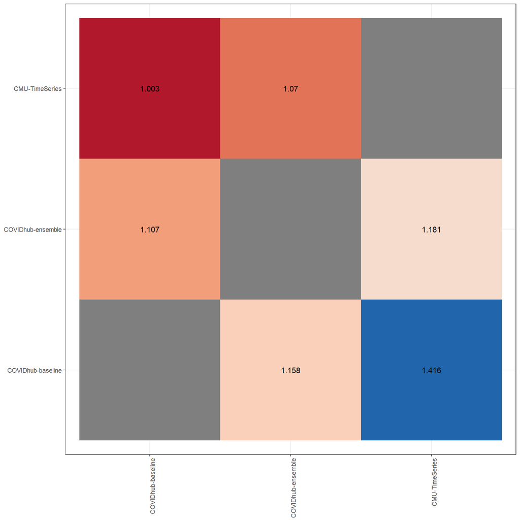

```r
theta_county = pairwise_tournament(score_cards_county, var = "wis", aggr =
                              function(x) mean(x, trim = 0.01, na.rm = TRUE))

ranked_list = rownames(theta_county$mat)[order(theta_county$vec1)]
colors = colorRampPalette(brewer.pal(n = 6, name = "RdBu"))(30)
ggplot(theta_county$df, aes(x = factor(Forecaster2, levels = rev(ranked_list)),
                     y = factor(Forecaster1, levels = rev(ranked_list)))) +
  geom_tile(aes(fill = value)) +
  geom_text(aes(label = round(value, 3))) +
  scale_fill_gradientn(colours = colors) +
  labs(x = NULL, y = NULL) +
  theme_bw() + theme(legend.position = "none",
                     axis.text.x = element_text(angle = 90, hjust = 1))
```

```r
# Overall metric (computed via GM of pairwise metrics):
knitr::kable(data.frame(rank = 1:length(theta_county$vec1), forecaster = ranked_list,
                        theta_county = sort(theta_county$vec1), row.names = NULL))
```

| rank | forecaster | theta_county |
| --- | --- | --- |
| 1 | CMU-TimeSeries | 1.036029 |
| 2 | COVIDhub-ensemble | 1.143763 |
| 3 | COVIDhub-baseline | 1.280746 |

For curiosity, we can plot the agreement the overall metric computed via GM and SVD. The agreement is basically perfect!

### State

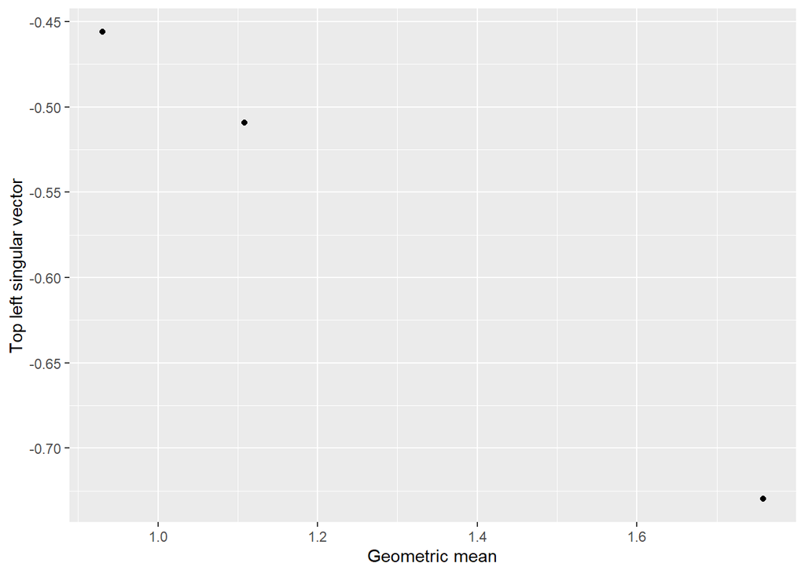

```r
ggplot() + geom_point(aes(x = theta_state$vec1, y = theta_state$vec2)) +
  labs(x = "Geometric mean", y = "Top left singular vector")
```

### County

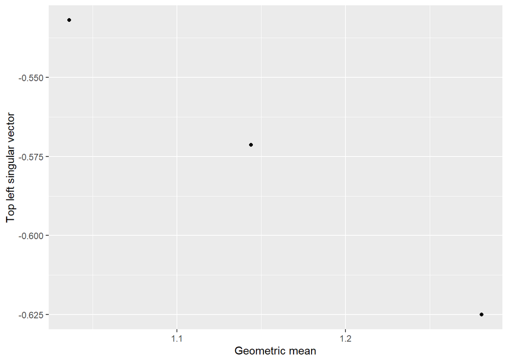

```r
ggplot() + geom_point(aes(x = theta_county$vec1, y = theta_county$vec2)) +
  labs(x = "Geometric mean", y = "Top left singular vector")
```

## Pairwise tournament: median and 90th percentile

Repeat the same pairwise tournament but with the median as the aggregator.

### State

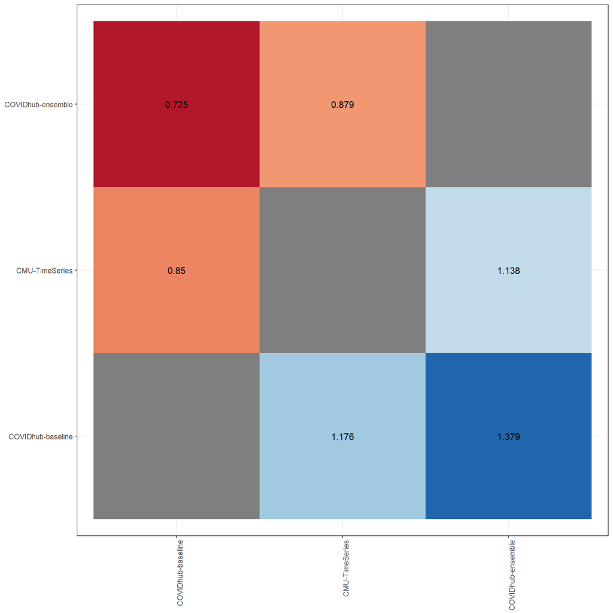

```r
theta_state = pairwise_tournament(score_cards_state, var = "wis", aggr = Median)

ranked_list = rownames(theta_state$mat)[order(theta_state$vec1)]
colors = colorRampPalette(brewer.pal(n = 6, name = "RdBu"))(30)
ggplot(theta_state$df, aes(x = factor(Forecaster2, levels = rev(ranked_list)),
                     y = factor(Forecaster1, levels = rev(ranked_list)))) +
  geom_tile(aes(fill = value)) +
  geom_text(aes(label = round(value, 3))) +
  scale_fill_gradientn(colours = colors) +
  labs(x = NULL, y = NULL) +
  theme_bw() + theme(legend.position = "none",
                     axis.text.x = element_text(angle = 90, hjust = 1))
```

```r
# Overall metric (computed via GM of pairwise metrics):
knitr::kable(data.frame(rank = 1:length(theta_state$vec1), forecaster = ranked_list,
                        theta_state = sort(theta_state$vec1), row.names = NULL))
```

| rank | forecaster | theta_state |
| --- | --- | --- |
| 1 | COVIDhub-ensemble | 0.7982900 |
| 2 | CMU-TimeSeries | 0.9833544 |
| 3 | COVIDhub-baseline | 1.2738822 |

### County

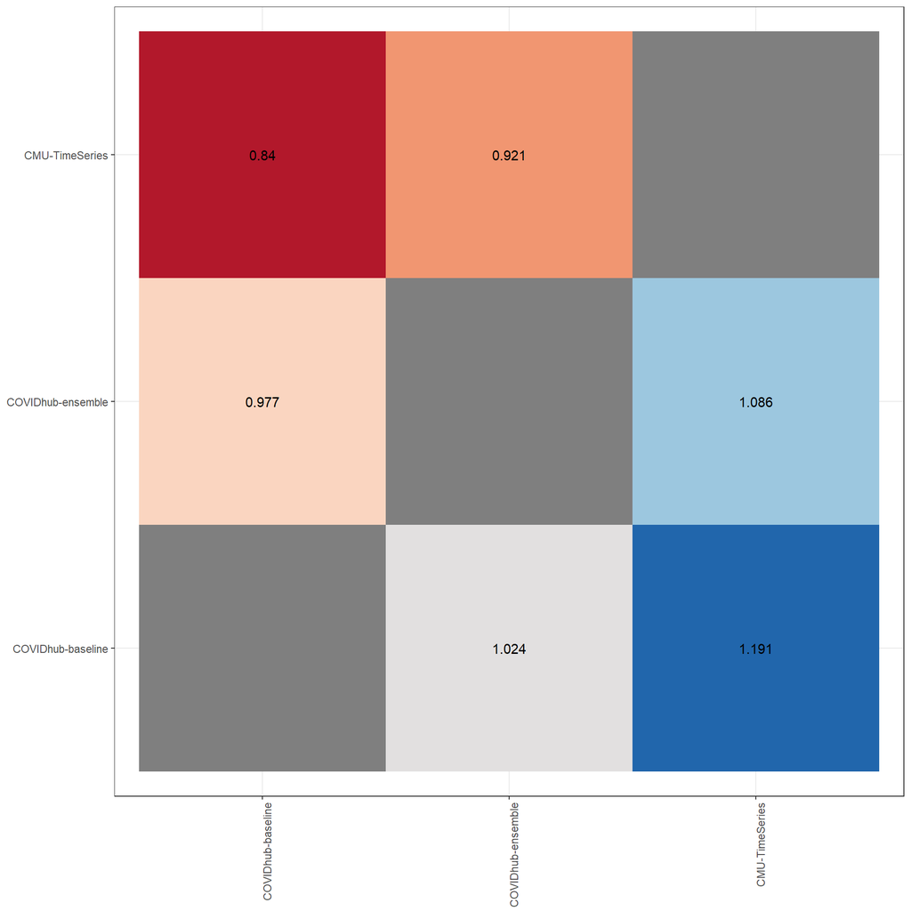

```r
theta_county = pairwise_tournament(score_cards_county, var = "wis", aggr = Median)

ranked_list = rownames(theta_county$mat)[order(theta_county$vec1)]
colors = colorRampPalette(brewer.pal(n = 6, name = "RdBu"))(30)
ggplot(theta_county$df, aes(x = factor(Forecaster2, levels = rev(ranked_list)),
                     y = factor(Forecaster1, levels = rev(ranked_list)))) +
  geom_tile(aes(fill = value)) +
  geom_text(aes(label = round(value, 3))) +
  scale_fill_gradientn(colours = colors) +
  labs(x = NULL, y = NULL) +
  theme_bw() + theme(legend.position = "none",
                     axis.text.x = element_text(angle = 90, hjust = 1))
```

```r
# Overall metric (computed via GM of pairwise metrics):
knitr::kable(data.frame(rank = 1:length(theta_county$vec1), forecaster = ranked_list,
                        theta_county = sort(theta_county$vec1), row.names = NULL))
```

| rank | forecaster | theta_county |
| --- | --- | --- |
| 1 | CMU-TimeSeries | 0.8793877 |
| 2 | COVIDhub-ensemble | 1.0298873 |
| 3 | COVIDhub-baseline | 1.1041546 |

And now with the 90th percentile as the aggregator.

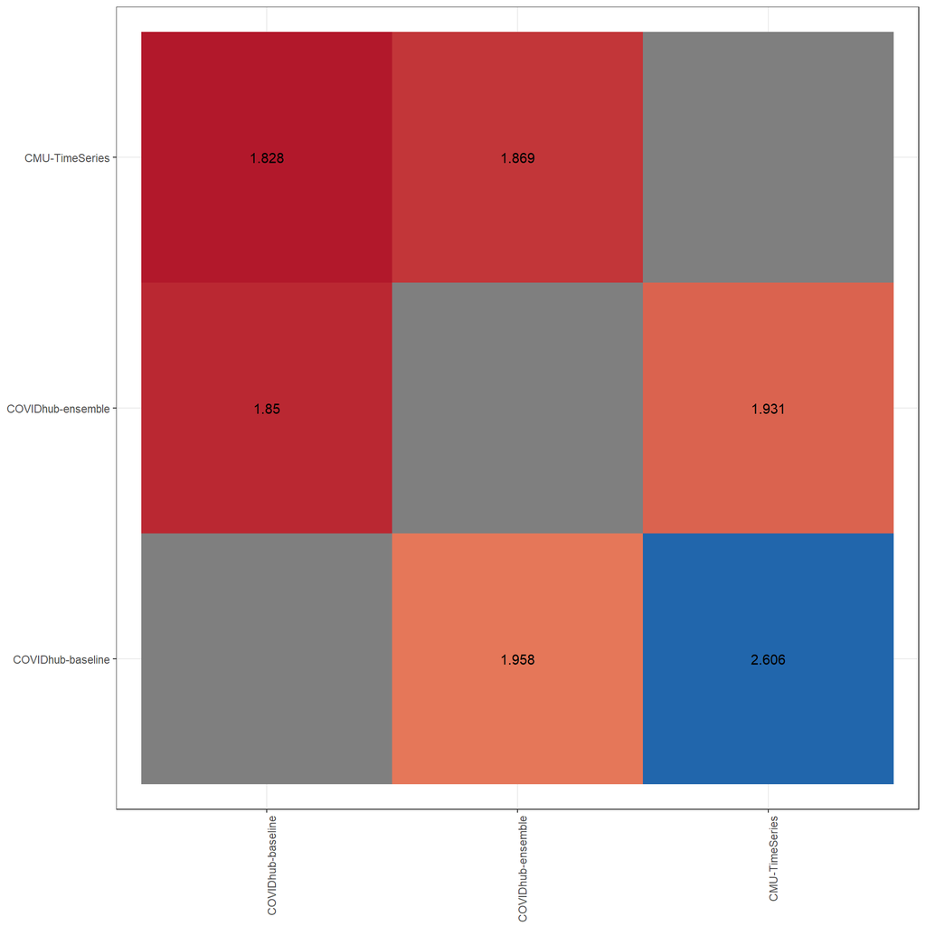

```r
theta_state = pairwise_tournament(score_cards_county, var = "wis", aggr =
                              function(x) quantile(x, prob = 0.9, na.rm = TRUE))

ranked_list = rownames(theta_state$mat)[order(theta_state$vec1)]
colors = colorRampPalette(brewer.pal(n = 6, name = "RdBu"))(30)
ggplot(theta_state$df, aes(x = factor(Forecaster2, levels = rev(ranked_list)),
                     y = factor(Forecaster1, levels = rev(ranked_list)))) +
  geom_tile(aes(fill = value)) +
  geom_text(aes(label = round(value, 3))) +
  scale_fill_gradientn(colours = colors) +
  labs(x = NULL, y = NULL) +
  theme_bw() + theme(legend.position = "none",
                     axis.text.x = element_text(angle = 90, hjust = 1))
```

```r
# Overall metric (computed via GM of pairwise metrics):
knitr::kable(data.frame(rank = 1:length(theta_state$vec1), forecaster = ranked_list,
                        theta_state = sort(theta_state$vec1), row.names = NULL))
```

| rank | forecaster | theta_state |
| --- | --- | --- |
| 1 | CMU-TimeSeries | 1.848242 |
| 2 | COVIDhub-ensemble | 1.890310 |
| 3 | COVIDhub-baseline | 2.259309 |

### County

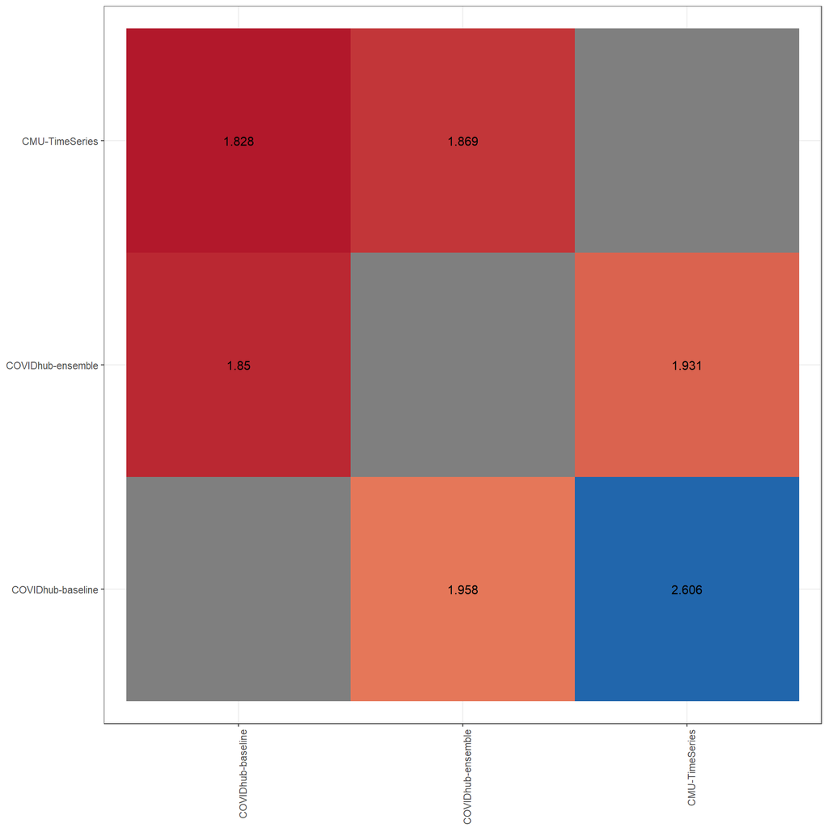

```r
theta_county = pairwise_tournament(score_cards_county, var = "wis", aggr =
                              function(x) quantile(x, prob = 0.9, na.rm = TRUE))

ranked_list = rownames(theta_county$mat)[order(theta_county$vec1)]
colors = colorRampPalette(brewer.pal(n = 6, name = "RdBu"))(30)
ggplot(theta_county$df, aes(x = factor(Forecaster2, levels = rev(ranked_list)),
                     y = factor(Forecaster1, levels = rev(ranked_list)))) +
  geom_tile(aes(fill = value)) +
  geom_text(aes(label = round(value, 3))) +
  scale_fill_gradientn(colours = colors) +
  labs(x = NULL, y = NULL) +
  theme_bw() + theme(legend.position = "none",
                     axis.text.x = element_text(angle = 90, hjust = 1))
```

```r
# Overall metric (computed via GM of pairwise metrics):
knitr::kable(data.frame(rank = 1:length(theta_county$vec1), forecaster = ranked_list,
                        theta_county = sort(theta_county$vec1), row.names = NULL))
```

| rank | forecaster | theta_county |
| --- | --- | --- |
| 1 | CMU-TimeSeries | 1.848242 |
| 2 | COVIDhub-ensemble | 1.890310 |
| 3 | COVIDhub-baseline | 2.259309 |